# DATA 607 assignment 5A:Airline Delays

Lionel jr. desroses

2026-10-01

##Introduction

For this assignment, I will analyze airline arrival performance data for Alaska Airlines and AmWest across five destinations. The data is currently presented in a wide format, so my first step will be to recreate the table as a CSV file and upload it to GitHub. After importing the data into R, I will use the tidyr and dplyr packages to transform the dataset into a tidy format for easier analysis.Once the data has been cleaned and organized, I will calculate delay and on-time percentages for each airline. I will compare the airlines both overall and by individual city to determine which airline has the better arrival performance. I also plan to create tables and visualizations to help illustrate the results and identify any patterns in the data.

My approach for this assignments is to first create a CSV file from the airline delay data provided, and then I will recreate the table in the same format as shown, including all airlines, destinations, and arrival status counts. After creating the CSV file, I will upload it to my GitHub repository so that the data file is stored in an accessible location and can be referenced in my project. Next, I will import the CSV file into R and examine the dataset’s structure. Once the data has been loaded, I will use the tidyr and dplyr packages to clean and transform the data. Specifically, I will convert the dataset from a wide format into a tidy long format using pivot_longer, making it easier to analyze.After tidying the data, I will calculate the total number of flights, delayed flights, and on-time flights for each airline. I will then compute delay percentages and compare the overall performance of Alaska Airlines and AmWest. Following the overall comparison, I will analyze the delay percentages for each destination city to assess how the airlines perform at each location. To better present the results, I will create tables and visualizations showing the delay rates by airline and destination. And then I will summarize my findings and discuss any differences between the overall airline performance and the city-by-city results. I will explain why these differences occur and what they reveal about the data. Once the analysis is complete, I will publish the R Markdown file to RPubs and provide links to both my GitHub repository and RPubs submission.

One challenge I anticipate is correctly transforming the data from its original wide format to a tidy long format while preserving the relationships among airlines, flight status, and destinations. Another challenge may be interpreting the results if the overall airline rankings differ from the city-by-city comparisons, since this requires careful analysis of percentages rather than simply comparing raw counts.

## Original structure

The original dataset is stored in a wide format. Each row represents an airline-arrival-status combination, while each city is represented by a separate column. Although this format is easy for humans to read, it is not ideal for analysis because city names are stored as column headers rather than observations.

```r
library(readr)
airline <- read_csv("https://raw.githubusercontent.com/lioneljr17/LDATA607/refs/heads/main/607LAB5A/airline_table.csv")
View(airline)
```

## tarnforming wide to long

To create a tidy dataset, I used the pivot_longer() function from the tidyr package. This transformation converts the city columns into a single City variable and places the corresponding counts into a Count variable. The resulting dataset contains one observation per row and is easier to summarize and visualize.

```r
airline_long <- airline %>%
  pivot_longer(cols =LosAngeles:Seattle,
                names_to ="city",
                values_to ="Count")

airline_long
```

```
## # A tibble: 20 × 4
##    Airline Status  city         Count
##    <chr>   <chr>   <chr>        <dbl>
##  1 ALASKA  On time LosAngeles     497
##  2 ALASKA  On time Phoenix        221
##  3 ALASKA  On time SanDiego       212
##  4 ALASKA  On time SanFrancisco   503
##  5 ALASKA  On time Seattle       1841
##  6 ALASKA  Delayed LosAngeles      62
##  7 ALASKA  Delayed Phoenix         12
##  8 ALASKA  Delayed SanDiego        20
##  9 ALASKA  Delayed SanFrancisco   102
## 10 ALASKA  Delayed Seattle        305
## 11 AMWEST  On time LosAngeles     694
## 12 AMWEST  On time Phoenix       4840
## 13 AMWEST  On time SanDiego       383
## 14 AMWEST  On time SanFrancisco   320
## 15 AMWEST  On time Seattle        201
## 16 AMWEST  Delayed LosAngeles     117
## 17 AMWEST  Delayed Phoenix        415
## 18 AMWEST  Delayed SanDiego        65
## 19 AMWEST  Delayed SanFrancisco   129
## 20 AMWEST  Delayed Seattle         61
```

```r
city_summary <- airline_long %>%
  group_by(Airline,city)%>%
  summarize (
    total = sum(Count),
    Delayed = Count[Status =="Delayed"],
    DelayedRate = round(100*Delayed/total,2),
    .groups ="drop"
  )

city_summary
```

```
## # A tibble: 10 × 5
##    Airline city         total Delayed DelayedRate
##    <chr>   <chr>        <dbl>   <dbl>       <dbl>
##  1 ALASKA  LosAngeles     559      62       11.1
##  2 ALASKA  Phoenix        233      12        5.15
##  3 ALASKA  SanDiego       232      20        8.62
##  4 ALASKA  SanFrancisco   605     102       16.9
##  5 ALASKA  Seattle       2146     305       14.2
##  6 AMWEST  LosAngeles     811     117       14.4
##  7 AMWEST  Phoenix       5255     415        7.9
##  8 AMWEST  SanDiego       448      65       14.5
##  9 AMWEST  SanFrancisco   449     129       28.7
## 10 AMWEST  Seattle        262      61       23.3
```

```r
overall_summary <- airline_long %>%
  group_by(Airline,city)%>%
  summarize (
    total = sum(Count),
    Delayed = Count[Status =="Delayed"],
    DelayedRate = round(100*Delayed/total,2),
    .groups ="drop"
  )
names(airline_long)
```

```
## [1] "Airline" "Status"  "city"    "Count"
```

```r
head(airline_long)
```

```
## # A tibble: 6 × 4
##   Airline Status  city         Count
##   <chr>   <chr>   <chr>        <dbl>
## 1 ALASKA  On time LosAngeles     497
## 2 ALASKA  On time Phoenix        221
## 3 ALASKA  On time SanDiego       212
## 4 ALASKA  On time SanFrancisco   503
## 5 ALASKA  On time Seattle       1841
## 6 ALASKA  Delayed LosAngeles      62
```

```r
unique(airline_long$Status)
```

```
## [1] "On time" "Delayed"
```

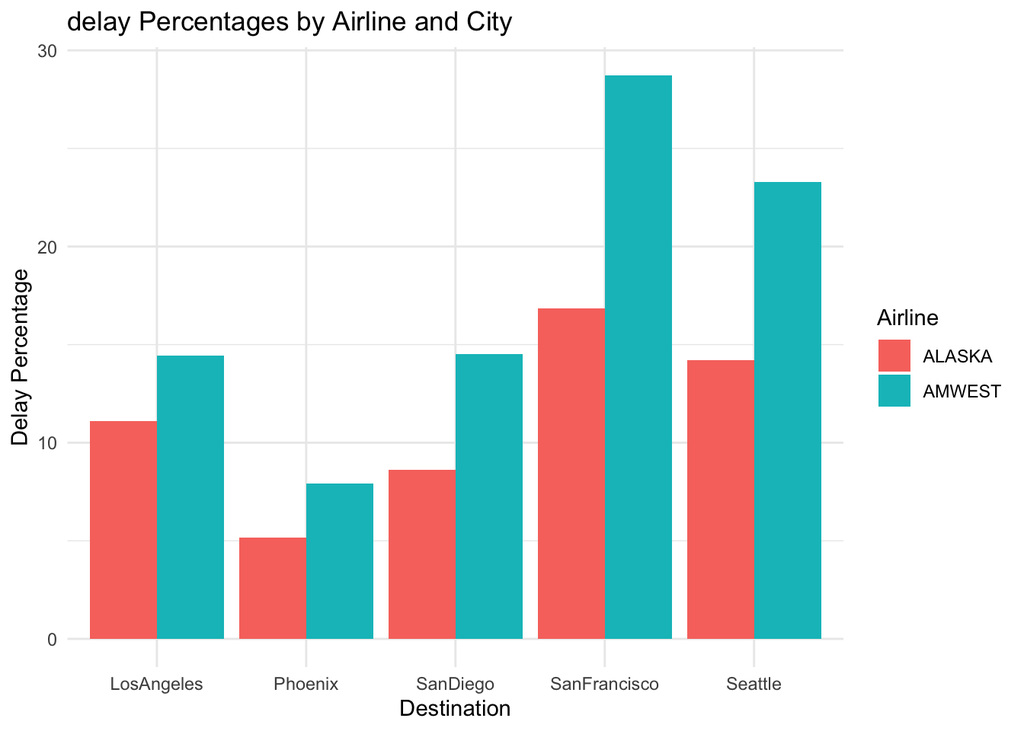

```r
ggplot(city_summary,aes(x =city,y=DelayedRate, fill = Airline))+
  geom_col(position ="dodge")+
  labs(title = "delay Percentages by Airline and City",
       x ="Destination",
       y ="Delay Percentage")+ theme_minimal()
```